# Reproducible Research: Peer Assessment 1

### Introduction

#### It is now possible to collect a large amount of data about personal movement using activity monitoring devices such as a Fitbit, Nike Fuelband, or Jawbone Up. These type of devices are part of the “quantified self” movement – a group of enthusiasts who take measurements about themselves regularly to improve their health, to find patterns in their behavior, or because they are tech geeks. But these data remain under-utilized both because the raw data are hard to obtain and there is a lack of statistical methods and software for processing and interpreting the data.

#### This assignment makes use of data from a personal activity monitoring device. This device collects data at 5 minute intervals through out the day. The data consists of two months of data from an anonymous individual collected during the months of October and November, 2012 and include the number of steps taken in 5 minute intervals each day.

#### Dataset: Activity monitoring data [52K]

#### The variables included in this dataset are:

#### **steps**: Number of steps taking in a 5-minute interval (missing values are coded as NA)

#### **date**: The date on which the measurement was taken in YYYY-MM-DD format

#### **interval**: Identifier for the 5-minute interval in which measurement was taken

#### The dataset is stored in a comma-separated-value (CSV) file and there are a total of 17,568 observations in this dataset.

### Loading and preprocessing the data

#### - load necessary libraries

```r
library(dplyr)
library(lubridate)
```

#### - download, unzip and load the data set

```r
dataset_url <- "https://d396qusza40orc.cloudfront.net/repdata%2Fdata%2Factivity.zip"
temp_zip <- tempfile()
download.file(dataset_url, temp_zip)
data_file <- unzip(temp_zip)
unlink(temp_zip)
data_set <- read.table(data_file, header = TRUE, sep = ',', na.strings = 'NA')
file.remove(data_file)
```

#### - convert date to Date

```r
data_set$date <- ymd(data_set$date)
```

### What is mean and median number of steps taken per day?

#### - calculate the total number of steps taken per day

```r
StepsByDate <- summarise(group_by(data_set, date), steps = sum(steps))
```

#### - calculate mean and median number of steps taken each day

```r
StepsMean <- mean(StepsByDate$steps, na.rm = TRUE)
StepsMedian <- median(StepsByDate$steps, na.rm = TRUE)
```

#### - histogram of the total number of steps taken each day and show mean and median

[figure not shown]

```r
hist(StepsByDate$steps, main = 'The total number of steps taken per day', xlab = 'Steps')
abline(v = StepsMean, col = 'green')
abline(v = StepsMedian, col = 'red')
```

#### Mean value of the total number of steps taken per day is 10766.1886792453 and median value is 10765.

### What is the average daily activity pattern?

#### - calculate the average number of steps taken per each interval across all days

```r
StepsByInterval <- summarise(group_by(data_set, interval), avg_steps = mean(steps, na.rm = TRUE))
```

#### - find interval with the maximum number of steps

```r
MaxInterval <- as.numeric(StepsByInterval[which.max(StepsByInterval$avg_steps), 1])
```

#### - make a time series plot of the average number of steps taken per interval

#### (show interval with the maximum number of steps)

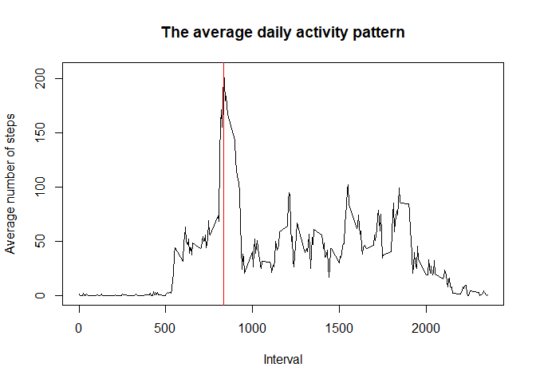

```r
with(StepsByInterval, plot(interval, avg_steps,
                        type = 'l', main = 'The average daily activity pattern',
                        xlab = 'Interval', ylab = 'Average number of steps'))
abline(v = MaxInterval, col = 'red')
```

#### The 5-minute interval with the maximum average number of steps taken is 835.

### Imputing missing values

#### - calculate the total number of missing values in the data set

```r
NrOfNA <- sum(is.na(data_set$steps))
```

#### The total number of missing values in the dataset is 2304.

#### A strategy for filling in all of the missing values in the dataset - use the mean of the same 5-minute interval.

#### - create a new data set with the missing data filled in

```r
data_set2 <- mutate(group_by(data_set,interval),
                    steps = ifelse(is.na(steps), mean(steps, na.rm = TRUE), steps))
```

#### - calculate the total number of steps taken per day

```r
StepsByDate2 <- summarise(group_by(data_set2, date), steps = sum(steps))
```

#### - calculate mean and median number of steps taken each day

```r
StepsMean2 <- mean(StepsByDate2$steps)
StepsMedian2 <- median(StepsByDate2$steps)
```

#### - histogram of the total number of steps taken each day and show mean and median

[figure not shown]

```r
hist(StepsByDate2$steps, main = 'The total number of steps taken per day (imputed missing values)', xlab = 'Steps')
abline(v = StepsMean2, col = 'green')
abline(v = StepsMedian2, col = 'red')
```

### Are there differences in activity patterns between weekdays and weekends?

#### - create a new factor variable in the data set with two levels - “weekday” and “weekend”

#### (NB! my locale is Estonian)

```r
data_set2$wday <- as.factor(ifelse(weekdays(data_set2$date, abbreviate = TRUE) %in% c('L','P'),'weekend', 'weekday'))
```

#### - calculate the average number of steps taken per each interval separately for weekdays and weekends

```r
StepsByIntervalWD <- summarise(group_by(subset(data_set2, wday == 'weekday'), interval), avg_steps = mean(steps))
StepsByIntervalWE <- summarise(group_by(subset(data_set2, wday == 'weekend'), interval), avg_steps = mean(steps))
```

#### - create panel plot

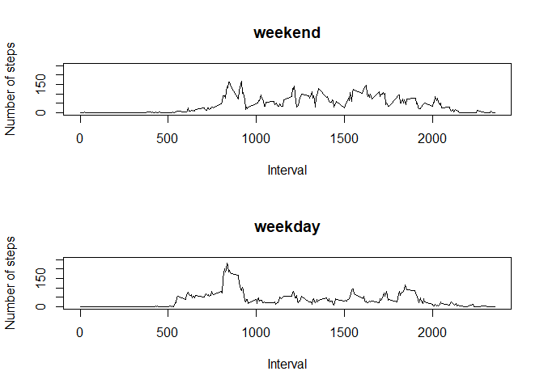

```r
par(mfrow = c(2, 1))
with(StepsByIntervalWE, plot(interval, avg_steps, type = 'l',
                             main = 'weekend',  xlab = 'Interval', ylab = 'Number of steps', ylim = c(0, 250)))
with(StepsByIntervalWD, plot(interval, avg_steps, type = 'l',
                             main = 'weekday',  xlab = 'Interval', ylab = 'Number of steps', ylim = c(0, 250)))
```

#### The figure shows that on the weekend activity is more evenly distributed throughout the day.